# Engineering data sets

## 1D) Pivoting Data: Reshaping from Long to Wide and Wide to Long

Data is often stored in **different formats**, depending on the analysis needs. Sometimes, we need to **widen** a dataset to make it easier to read, and other times, we need to **lengthen** it to perform certain operations. The `tidyr` package in `tidyverse` provides **pivoting functions** to reshape data efficiently.

- **Wide format**: Each row represents a single entity, with multiple columns for different variables.
- **Long format**: Each observation is in its own row, with a single column for values and an **additional column indicating the variable type**.

| Format | Example Structure | Example Dataset |
| --- | --- | --- |
| **Wide** | One row per date, multiple columns for weather indicator by country | `weather.csv` |
| **Long** | One row per artist-date-country combination, a column for streams | `streams.csv` |

### From Wide to Long: `pivot_longer()`

When converting **wide data** to **long format**, we gather multiple columns into key-value pairs. This is useful when variables are spread across columns but should be stored as rows.

Key arguments in `pivot_longer()`:

1. **`cols`** – Selects which columns to pivot.
   - Can specify by name (`c(BE_temp, DE_temp)`) or range (`BE_temp:US_temp`).
   - Use `-date` or `!date` to pivot everything except certain columns.
2. **`names_to`** – Defines where column names will be stored.
   - Example: `"country"` if columns like `DE_temp` and `BE_temp` should be labeled by country.
3. **`values_to`** – Defines where the actual data values go.
   - Example: `"temperature"` if numeric values from `DE_temp` and `BE_temp` represent temperature readings.

This transformation makes it easier to filter, group, and analyze structured data.

#### Example: Make `weather` data long by country

```r
long_weather <- weather %>%
  pivot_longer(cols = ends_with('temp'), names_to = "name", values_to = "temperature") %>% separate(name, into = c('country','variable'), sep='_') %>% select(date, country, temperature)

head(long_weather)
```

```
## # A tibble: 6 × 3
##   date       country temperature
##   <date>     <chr>         <dbl>
## 1 2024-01-01 DE            14.3
## 2 2024-01-01 BE            10.5
## 3 2024-01-01 NL            10.6
## 4 2024-01-01 US            17.1
## 5 2024-01-02 DE             8.72
## 6 2024-01-02 BE            17.1
```

**Before pivoting (wide format)**:

[output not shown]

**After pivoting (long format)**:

[output not shown]

### From Long to Wide: `pivot_wider()`

When converting **long data** to **wide format**, we spread values across multiple columns, making the dataset easier to read and analyze.

Key arguments in `pivot_wider()`:

1. **`id_cols`** – Specifies the column(s) that should remain unchanged.
   - Example: `"date"` if we want to keep dates as row identifiers while spreading other values.
   - If not specified, `pivot_wider()` assumes all non-selected columns should be spread.
2. **`names_from`** – Defines which column contains the new column names.
   - Example: `"country"` if values from `"country"` (`DE`, `BE`, `NL`) should become separate columns.
3. **`values_from`** – Specifies which column contains the data to be spread across new columns.
   - Example: `"temperature"` if we want each country's temperature as its own column.

This transformation is useful when preparing data for reports, modeling, or visualizations.

#### Example: Make `long_weather` wide again

```r
wide_weather <- long_weather %>%
  pivot_wider(names_from = 'country', values_from = 'temperature')

head(wide_weather)
```

```
## # A tibble: 6 × 5
##   date          DE    BE    NL    US
##   <date>     <dbl> <dbl> <dbl> <dbl>
## 1 2024-01-01 14.3  10.5  10.6   17.1
## 2 2024-01-02  8.72 17.1  10.4   21.8
## 3 2024-01-03 11.7   7.41 11.7   17.4
## 4 2024-01-04 12.7  10.5   8.78  15.3
## 5 2024-01-05 12.2  13.0   9.82  29.3
## 6 2024-01-06 10.9  17.0  13.4   13.3
```

**Before pivoting (long format)**:

[output not shown]

**After pivoting (wide format)**:

[output not shown]

For more details, check out the **tidyverse cheatsheet on pivoting**:  
[tidyr Pivoting Cheatsheet](https://raw.githubusercontent.com/rstudio/cheatsheets/main/tidyr.pdf)

## 1E) Merging Data: Combining Multiple Data Sources

In real-world analysis, data is often stored in separate tables. To get meaningful insights, we need to merge datasets based on shared keys. The `dplyr` package provides efficient functions for this, making it easy to combine and manipulate data.

Joins allow us to merge two datasets by matching values in a **key column**. Here’s an overview of different join types:

### Join types

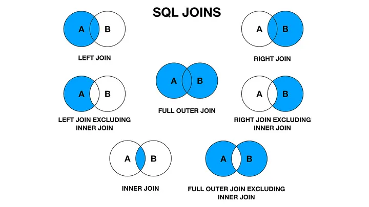

Common Join Types

**Here, we will focus on the most important ones:**

| Join Type | Keeps All Rows From | Drops Rows? |
| --- | --- | --- |
| **Left Join (`left_join()`)** | Left table | No |
| **Inner Join (`inner_join()`)** | Only matching rows | Yes |
| **Right Join (`right_join()`)** | Right table | No |
| **Full Join (`full_join()`)** | Both tables (fills missing values) | No |

The **left join is the default choice** in most cases because it keeps all rows from the left dataset and only adds matching values from the right. Inner joins should be used with caution because they remove rows that do not have a match.

### What Are Keys in a Join?

To merge data correctly, we need **keys**—columns that uniquely identify records in each dataset.

- **Single key**: Merging by a single column like `"date"`.
- **Composite key**: Merging by multiple columns like `"date"` and `"artist"`.

Without defining a proper key, the merge may not work as expected, or it may introduce duplicate rows.

### Examples of Joins in Action

#### Example: Left Join (Recommended)

Merging `streams` with `playlists`, keeping all rows from `streams`.

```r
# For this exercise, let's add a week column that we can merge on
streams <- streams %>% mutate(week=ISOweek::ISOweek(date))

merged_data <- streams %>%
  left_join(playlists, by = c("artist" = "artist",
                              "week"="iso_week"))  # Keeps all stream data, adds playlist info.

# Note: here we specify that "week" in the LEFT data frame (streams) is matched on the "iso_week" column in the RIGHT data frame (playlists).

head(merged_data)
```

```
## # A tibble: 6 × 13
## # Groups:   artist, country [6]
##   date       artist country streams trend week  week2 month  year streams_filled
##   <date>     <chr>  <chr>     <dbl> <int> <chr> <chr> <dbl> <dbl>          <dbl>
## 1 2024-01-01 10 Be… BE         6983     1 2024… 2024…     1  2024           6983
## 2 2024-01-01 10 Be… DE         9523     2 2024… 2024…     1  2024           9523
## 3 2024-01-01 10 Be… NL         6258     3 2024… 2024…     1  2024           6258
## 4 2024-01-01 10 Be… US         2856     4 2024… 2024…     1  2024           2856
## 5 2024-01-01 10 No… BE         7186     1 2024… 2024…     1  2024           7186
## 6 2024-01-01 10 No… DE         4173     2 2024… 2024…     1  2024           4173
## # ℹ 3 more variables: lag_streams <dbl>, daily_change <dbl>, playlists <dbl>
```

**Why use a left join?**

- All streaming data remains intact.
- Playlist data is added where available, but missing values appear if no match is found.
- This is useful when missing data in playlists should not remove streaming records.

#### Example: Inner Join (Only Matching Rows)

Keeps only rows where a match exists in both `streams` and `socials`.

```r
tiktok_followers = socials %>% filter(platform=='TikTok'  & metric == 'followers')

merged_data <- streams %>%
  inner_join(tiktok_followers, by = c("date", "artist"))  # Match by both columns

# rename value column
merged_data = merged_data %>% mutate(tiktok_followers = value) %>% select(-platform, -metric, -value)

head(merged_data)
```

```
## # A tibble: 6 × 13
## # Groups:   artist, country [6]
##   date       artist country streams trend week  week2 month  year streams_filled
##   <date>     <chr>  <chr>     <dbl> <int> <chr> <chr> <dbl> <dbl>          <dbl>
## 1 2024-01-01 10 Be… BE         6983     1 2024… 2024…     1  2024           6983
## 2 2024-01-01 10 Be… DE         9523     2 2024… 2024…     1  2024           9523
## 3 2024-01-01 10 Be… NL         6258     3 2024… 2024…     1  2024           6258
## 4 2024-01-01 10 Be… US         2856     4 2024… 2024…     1  2024           2856
## 5 2024-01-01 10 No… BE         7186     1 2024… 2024…     1  2024           7186
## 6 2024-01-01 10 No… DE         4173     2 2024… 2024…     1  2024           4173
## # ℹ 3 more variables: lag_streams <dbl>, daily_change <dbl>,
## #   tiktok_followers <dbl>
```

Things to keep in mind:

- Rows are removed if an artist has streams but no corresponding social media data on that date.
- This join is only useful when seeking to analyze cases where **both datasets** must have relevant information.

Note: Before `dplyr`, R users relied on the `merge()` function from base R. It works similarly but is less readable and much slower. In other words: please use `tidyverse`/`dplyr`.

For more details, check out the official **dplyr cheatsheet** on joins:  
[Joins Cheatsheet](https://nyu-cdsc.github.io/learningr/assets/data-transformation.pdf)

## **You've Made It! 🎉**

Congratulations! You've tackled the **fundamentals of working with time in R**, from handling messy date formats to computing lags and filling in missing values. Now, it's time to put your skills to the test with a **real-world challenge**—one that reflects the types of problems you’d face in data analysis.